# R Notebook

```r
library(dplyr)
library(lubridate)
library(tidyverse)
library(tsibble)
library(tsibbledata)
library(feasts)

date1 <- ymd_hms("2017-04-22 22:01:18")
date2 <- ymd_hms("2001-11-07 10:09:56")
```

```r
library(nycflights13)
```

Dates and Times

Question 1

Extract the different components (year, month, mday, yday, wday) from the variable date1. Add the labels to the month and do not abbreviate the month labels.

```r
year(date1)
```

```
[1] 2017
```

```r
month(date1, label = TRUE, abbr = FALSE)
```

```
[1] April
12 Levels: January < February < March < April < May < June < ... < December
```

```r
mday(date1)
```

```
[1] 22
```

```r
yday(date1)
```

```
[1] 112
```

```r
wday(date1)
```

```
[1] 7
```

Question 2

Add 14 days to your date1 variable and store it in a variable called next_fortnight. Take away 10 years from your date2 variable, and store it in previous_decade.

```r
next_fortnight <- date1 + days(14)
previous_decade <- date2 - years(10)

next_fortnight
```

```
[1] "2017-05-06 22:01:18 UTC"
```

```r
previous_decade
```

```
[1] "1991-11-07 10:09:56 UTC"
```

Question 3

Create a variable called this_year which contains today’s date. Then create an interval object which uses this_year and the previous_decade variable you made above. Store it in interval_years. Hint: you’ll need to use lubridate::interval in order to get the right function, as tsibble has one too

```r
this_year <- ymd("2019-12-02")
interval_years <- lubridate::interval(this_year, previous_decade)
```

Question 4

Change the time zone of both your date variables to “America/New_York”, and call them nyc_date1 and nyc_date2.

```r
nyc_date1 <- with_tz(date1, "America/New_York")
nyc_date2 <- with_tz(date2, "America/New_York")

nyc_date1
```

```
[1] "2017-04-22 18:01:18 EDT"
```

```r
nyc_date2
```

```
[1] "2001-11-07 05:09:56 EST"
```

Question 5

Use the flights data from the nycflights13 dataset. Make a date-time column called departure_date from the year, month, day, hour, and minute variables in the flights tibble.

```r
departure_column <- flights %>%
  select(year, month, day, hour, minute) %>%
  mutate(departure_date = make_datetime(year, month, day, hour, minute))
departure_column
```

| year | month | day | hour | minute | departure_date |
| --- | --- | --- | --- | --- | --- |
| 2013 | 1 | 1 | 5 | 15 | 2013-01-01 05:15:00 |
| 2013 | 1 | 1 | 5 | 29 | 2013-01-01 05:29:00 |
| 2013 | 1 | 1 | 5 | 40 | 2013-01-01 05:40:00 |
| 2013 | 1 | 1 | 5 | 45 | 2013-01-01 05:45:00 |
| 2013 | 1 | 1 | 6 | 0 | 2013-01-01 06:00:00 |
| 2013 | 1 | 1 | 5 | 58 | 2013-01-01 05:58:00 |
| 2013 | 1 | 1 | 6 | 0 | 2013-01-01 06:00:00 |
| 2013 | 1 | 1 | 6 | 0 | 2013-01-01 06:00:00 |
| 2013 | 1 | 1 | 6 | 0 | 2013-01-01 06:00:00 |
| 2013 | 1 | 1 | 6 | 0 | 2013-01-01 06:00:00 |

[output cut: 990 more lines]

Time series familiarity

Question 6

Start with the weather data from the nycflights13 package. Select all the variables related to temperature, humidity, and precipitation, and pick out the key and index variables. Have a look at your data, and write a small description of the time series you observe.

Question 7

Change the weather data into a tsibble.

```r
weather
```

| origin | year | month | day | hour | temp | dewp | humid | wind_dir | wind_speed | wind_gust | precip | pressure | visib | time_hour |
| --- | --- | --- | --- | --- | --- | --- | --- | --- | --- | --- | --- | --- | --- | --- |
| EWR | 2013 | 1 | 1 | 1 | 39.02 | 26.06 | 59.37 | 270 | 10.35702 | NA | 0.00 | 1012.0 | 10.00 | 2013-01-01 01:00:00 |
| EWR | 2013 | 1 | 1 | 2 | 39.02 | 26.96 | 61.63 | 250 | 8.05546 | NA | 0.00 | 1012.3 | 10.00 | 2013-01-01 02:00:00 |
| EWR | 2013 | 1 | 1 | 3 | 39.02 | 28.04 | 64.43 | 240 | 11.50780 | NA | 0.00 | 1012.5 | 10.00 | 2013-01-01 03:00:00 |
| EWR | 2013 | 1 | 1 | 4 | 39.92 | 28.04 | 62.21 | 250 | 12.65858 | NA | 0.00 | 1012.2 | 10.00 | 2013-01-01 04:00:00 |
| EWR | 2013 | 1 | 1 | 5 | 39.02 | 28.04 | 64.43 | 260 | 12.65858 | NA | 0.00 | 1011.9 | 10.00 | 2013-01-01 05:00:00 |
| EWR | 2013 | 1 | 1 | 6 | 37.94 | 28.04 | 67.21 | 240 | 11.50780 | NA | 0.00 | 1012.4 | 10.00 | 2013-01-01 06:00:00 |
| EWR | 2013 | 1 | 1 | 7 | 39.02 | 28.04 | 64.43 | 240 | 14.96014 | NA | 0.00 | 1012.2 | 10.00 | 2013-01-01 07:00:00 |
| EWR | 2013 | 1 | 1 | 8 | 39.92 | 28.04 | 62.21 | 250 | 10.35702 | NA | 0.00 | 1012.2 | 10.00 | 2013-01-01 08:00:00 |
| EWR | 2013 | 1 | 1 | 9 | 39.92 | 28.04 | 62.21 | 260 | 14.96014 | NA | 0.00 | 1012.7 | 10.00 | 2013-01-01 09:00:00 |
| EWR | 2013 | 1 | 1 | 10 | 41.00 | 28.04 | 59.65 | 260 | 13.80936 | NA | 0.00 | 1012.4 | 10.00 | 2013-01-01 10:00:00 |

[output cut: 990 more lines]

```r
weather_tsbl <- as_tsibble(weather, key = origin)
```

```
Using `time_hour` as index variable.
```

```r
names(weather_tsbl)
```

```
 [1] "origin"     "year"       "month"      "day"        "hour"
 [6] "temp"       "dewp"       "humid"      "wind_dir"   "wind_speed"
[11] "wind_gust"  "precip"     "pressure"   "visib"      "time_hour"
```

```r
weather_variables <- weather_tsbl %>%
  select(origin, temp, humid, precip, time_hour)
weather_variables
```

| origin | temp | humid | precip | time_hour |
| --- | --- | --- | --- | --- |
| EWR | 39.02 | 59.37 | 0.00 | 2013-01-01 01:00:00 |
| EWR | 39.02 | 61.63 | 0.00 | 2013-01-01 02:00:00 |
| EWR | 39.02 | 64.43 | 0.00 | 2013-01-01 03:00:00 |
| EWR | 39.92 | 62.21 | 0.00 | 2013-01-01 04:00:00 |
| EWR | 39.02 | 64.43 | 0.00 | 2013-01-01 05:00:00 |
| EWR | 37.94 | 67.21 | 0.00 | 2013-01-01 06:00:00 |
| EWR | 39.02 | 64.43 | 0.00 | 2013-01-01 07:00:00 |
| EWR | 39.92 | 62.21 | 0.00 | 2013-01-01 08:00:00 |
| EWR | 39.92 | 62.21 | 0.00 | 2013-01-01 09:00:00 |
| EWR | 41.00 | 59.65 | 0.00 | 2013-01-01 10:00:00 |

[output cut: 990 more lines]

```r
weather_variables %>%
  distinct(origin)
```

| origin |
| --- |
| EWR |
| JFK |
| LGA |

Weather data collected hourly at three airports

Question 8

Add a year and month column to your weather data, and create a basic line plot which shows the temperature data from each airport over time. Have a think back to what you learned in visualisation week, and think about whether plotting the whole time series in one go is adequate here? Write down your suggestions for what could be done to make a better and more informative plot.

```r
weather_variables_time <- weather_variables %>%
  mutate(year = year(time_hour)) %>%
  mutate(month = month(time_hour))
weather_variables_time
```

| origin | temp | humid | precip | time_hour | year | month |
| --- | --- | --- | --- | --- | --- | --- |
| EWR | 39.02 | 59.37 | 0.00 | 2013-01-01 01:00:00 | 2013 | 1 |
| EWR | 39.02 | 61.63 | 0.00 | 2013-01-01 02:00:00 | 2013 | 1 |
| EWR | 39.02 | 64.43 | 0.00 | 2013-01-01 03:00:00 | 2013 | 1 |
| EWR | 39.92 | 62.21 | 0.00 | 2013-01-01 04:00:00 | 2013 | 1 |
| EWR | 39.02 | 64.43 | 0.00 | 2013-01-01 05:00:00 | 2013 | 1 |
| EWR | 37.94 | 67.21 | 0.00 | 2013-01-01 06:00:00 | 2013 | 1 |
| EWR | 39.02 | 64.43 | 0.00 | 2013-01-01 07:00:00 | 2013 | 1 |
| EWR | 39.92 | 62.21 | 0.00 | 2013-01-01 08:00:00 | 2013 | 1 |
| EWR | 39.92 | 62.21 | 0.00 | 2013-01-01 09:00:00 | 2013 | 1 |
| EWR | 41.00 | 59.65 | 0.00 | 2013-01-01 10:00:00 | 2013 | 1 |

[output cut: 990 more lines]

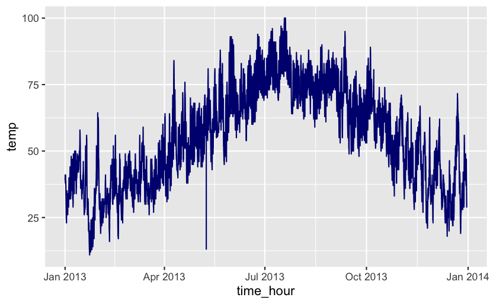

```r
weather_variables_time_plot <- weather_variables_time %>%
ggplot() +
  geom_line(aes(x = time_hour, y = temp), colour = "navy")
weather_variables_time_plot
```

Plotting hourly time points makes the graph cluttered. It would be better to aggregate.

```r
weather_date <- weather_variables_time %>%
  group_by_key(origin) %>%
  index_by(date = ~ as_date(.)) %>%
  summarise(temp_mean = mean(temp, na.rm = TRUE))
weather_date
```

| origin | date | temp_mean |
| --- | --- | --- |
| EWR | 2013-01-01 | 36.81909 |
| EWR | 2013-01-02 | 28.70000 |
| EWR | 2013-01-03 | 29.57750 |
| EWR | 2013-01-04 | 34.33250 |
| EWR | 2013-01-05 | 36.56000 |
| EWR | 2013-01-06 | 39.92000 |
| EWR | 2013-01-07 | 40.27250 |
| EWR | 2013-01-08 | 38.60750 |
| EWR | 2013-01-09 | 42.08000 |
| EWR | 2013-01-10 | 43.56500 |

[output cut: 990 more lines]

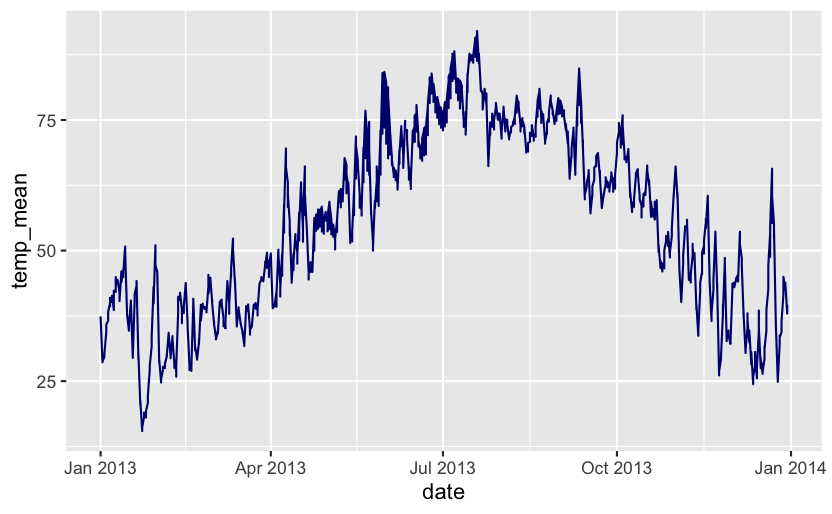

```r
weather_date_plot <- weather_date %>%
  ggplot(aes(x = date, y = temp_mean)) +
  geom_line(colour = "navy")
weather_date_plot
```

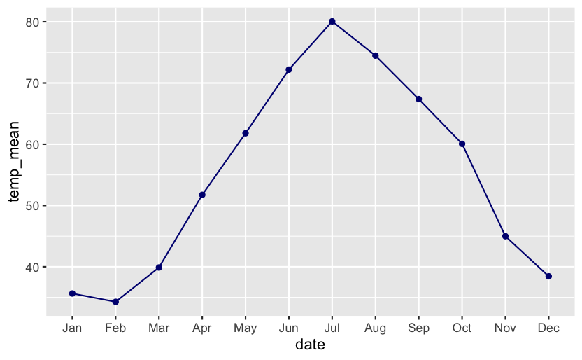

```r
weather_month <- weather_variables_time %>%
  index_by(date = ~ month(., label = TRUE)) %>%
  summarise(temp_mean = mean(temp, na.rm = TRUE)) %>%
ggplot(aes(x = date, y = temp_mean)) +
  geom_point(colour = "navy") +
  geom_line(group = 1, colour = "navy")

weather_month
```

Question 9

Choose an appropriate rolling window and calculate a moving average for your weather temperature data for each airport origin. Create a useful plot which overlays the original time series data and the rolling average data. Make sure the graph is easy for others to understand (Hint: you might want to facet_wrap). Finally, write a summary of why you chose the time window you did, and describe any trends you see.

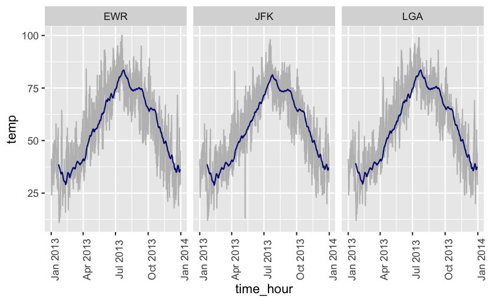

```r
weather_rolling <- weather_variables_time %>%
    group_by_key(origin) %>%
    mutate(temp_ma = slide_dbl(temp, ~ mean(., na.rm = TRUE), .size = 500)) %>%
ggplot() +
    geom_line(aes(x = time_hour, y = temp), colour = "grey") +
    geom_line(aes(x = time_hour, y = temp_ma), colour = "navy") +
    facet_wrap(vars(origin)) +
    theme(axis.text.x = element_text(angle = 90))
weather_rolling
```

I understand the concept of slide and tile, but not sure when a tile window would be used. I tried tile with this data, but it didn’t look right, so I went with slide, with which I was familiar from class. Trends show similar seasonal changes of temperature. Since these airports are relatively near to each other, the similar temperatures at time points are not surprising.

Question 10

Downsample your data so that you plot daily temperature data for each airport, instead of hourly data.

Oops, I think I did that in question 8

```r
weather_date <- weather_variables_time %>%
  group_by_key(origin) %>%
  index_by(date = ~ as_date(.)) %>%
  summarise(temp_mean = mean(temp, na.rm = TRUE))

weather_date
```

| origin | date | temp_mean |
| --- | --- | --- |
| EWR | 2013-01-01 | 36.81909 |
| EWR | 2013-01-02 | 28.70000 |
| EWR | 2013-01-03 | 29.57750 |
| EWR | 2013-01-04 | 34.33250 |
| EWR | 2013-01-05 | 36.56000 |
| EWR | 2013-01-06 | 39.92000 |
| EWR | 2013-01-07 | 40.27250 |
| EWR | 2013-01-08 | 38.60750 |
| EWR | 2013-01-09 | 42.08000 |
| EWR | 2013-01-10 | 43.56500 |

[output cut: 990 more lines]

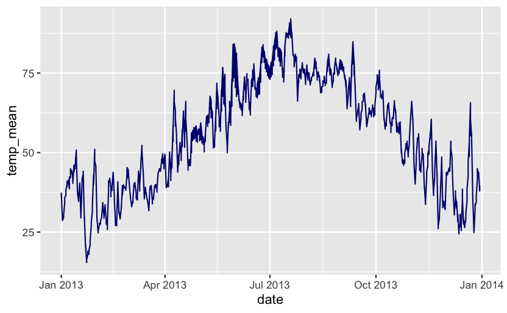

```r
weather_date_plot <- weather_date %>%
  ggplot(aes(x = date, y = temp_mean)) +
  geom_line(colour = "navy")
weather_date_plot
```

Question 11

Decompose your daily time series data (the downsampled one) using an appopriate downsampling technique. Justify your choice, and explain what the decomposition shows you. Does it tell you anything about the seasonality that you couldn’t see before?

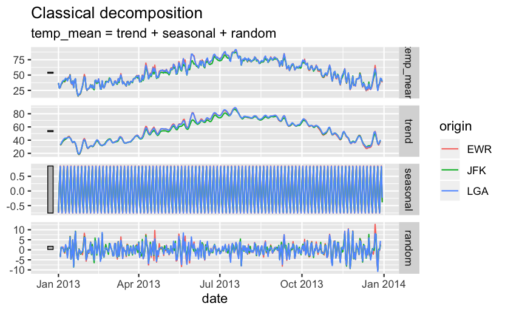

```r
weather_decomp <- weather_date %>%
  classical_decomposition(temp_mean ~ season(4), type = "additive") %>%
  autoplot()
weather_decomp
```

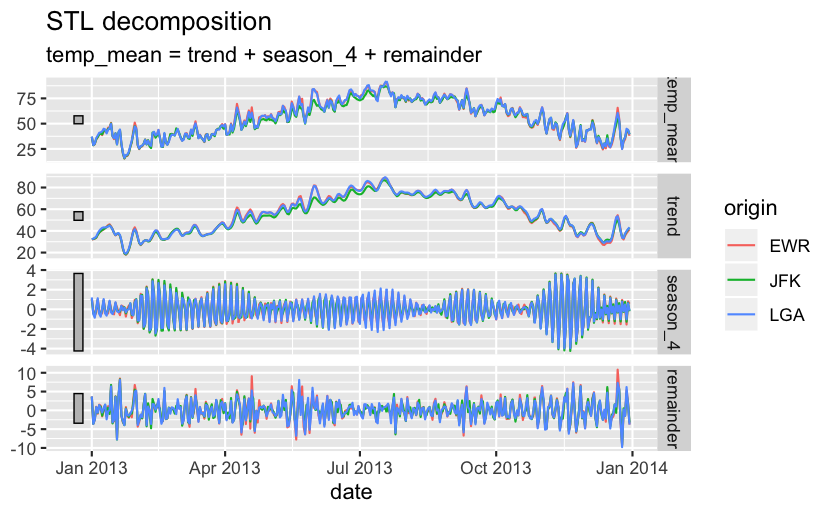

```r
weather_decomp_stl <- weather_date %>%
  STL(temp_mean ~ season(4)) %>%
  autoplot()
weather_decomp_stl
```

I tried both types of decomposition. I’m not entirely sure what I’m doing wrong. I obviously have access to the homework solutions now, since I’m doing this late, but I didn’t want to look before I tried on my own. After checking the homework answers, I can see that I should have put “4 months” instead of just 4. I also went back and added group_by_key(origin) to a couple of answers, because I had lost the origin column somewhere along the way. Everything looks much better now.

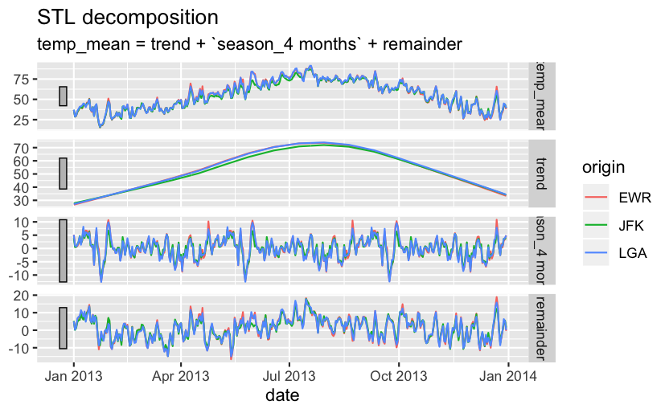

```r
weather_decomp_stl <- weather_date %>%
  STL(temp_mean ~ season("4 months")) %>%
  autoplot()
weather_decomp_stl
```

Question 12

Extract features from your downsampled data. Which airport has the strongest trend?

```r
weather_features <- weather_date %>%
  features(temp_mean, feature_set(tags = "stl"))

weather_features
```

| origin | trend_strength | seasonal_strength_week | spikiness | linearity | curvature | seasonal_peak_week | seasonal_trough_week |
| --- | --- | --- | --- | --- | --- | --- | --- |
| EWR | 0.9302530 | 0.1347611 | 0.010169620 | 82.79211 | -272.0870 | 3 | 2 |
| JFK | 0.9408080 | 0.1245818 | 0.005423894 | 93.14511 | -250.5166 | 1 | 6 |
| LGA | 0.9355984 | 0.1296838 | 0.007199975 | 89.61331 | -266.7822 | 3 | 2 |